# Vignette 2 - OSMtidy workflow

Dr Annie Visser-Quinn (a.visser-quinn@hw.ac.uk)

2021-01-11

This vignette describes the OSMtidy workflow. The workflow consists of six steps which are intended to be simple and easy to follow:

1. **Input** A shapefile outlining the location
2. **Extract** Spatial data – inside the shapefiles ‘bounding box’ – is extracted from [OpenStreetMaps](https://www.openstreetmap.org/) servers via the R package [osmdata](https://cran.r-project.org/web/packages/osmdata/index.html)
3. **Cut** The extracted data is ‘cookie cutter’-ed to the shapefile extent
4. **Wrangle** The data is transformed into a suitable format for filtering
5. **Filter** The physical objects are filtered and renamed to follow a simple naming convention
6. **Tidy** Collates the outputs to form a streamlined database of physical objects

This vignette also introduces to helper functions which can be applied at all of these six steps: `dataSummary()` and `dataExport()`.

To get started, you’ll need:

- An up to date install of the OSMtidy package. You can install or update OSMtidy using the package devtools: `devtools::install_github("avisserquinn/OSMtidy")`
- A shapefile (a single polygon) outline of the location you want to extract OSM data for

## 1. Input - Using dataShapefile()

Using the function `dataShapefile()` we can import the shapefile for which data is to be extracted. There are two input arguments:

- *filename* The filename or filepath of the shapefile
- *crs* Coordinate projection of the input data (optional). This function will automatically convert the shapefile to EPSG:4326 (https://epsg.io/4326)

```r
shp <- dataShapefile(filename = "exampleEdinburgh.shp", crs = 4326) # or dataShapefile("exampleEdinburgh.shp")
shp
```

```
## Simple feature collection with 1 feature and 0 fields
## geometry type:  POLYGON
## dimension:      XY
## bbox:           xmin: -3.199973 ymin: 55.95726 xmax: -3.162921 ymax: 55.97507
## geographic CRS: WGS 84
##                         geometry
## 1 POLYGON ((-3.162921 55.9633...
```

### 1.1 dataSummary()

At each step, you can print a summary of the OSMtidy outputs using the function `dataSummary()`.

```r
dataSummary(shp)
```

```
## $class
## [1] "sf"                    "data.frame"            "OSMtidy_dataShapefile"
##
## $shapeProjection
## Coordinate Reference System:
##   User input: EPSG:4326
##   wkt:
## GEOGCRS["WGS 84",
##     DATUM["World Geodetic System 1984",
##         ELLIPSOID["WGS 84",6378137,298.257223563,
##             LENGTHUNIT["metre",1]]],
##     PRIMEM["Greenwich",0,
##         ANGLEUNIT["degree",0.0174532925199433]],
##     CS[ellipsoidal,2],
##         AXIS["geodetic latitude (Lat)",north,
##             ORDER[1],
##             ANGLEUNIT["degree",0.0174532925199433]],
##         AXIS["geodetic longitude (Lon)",east,
##             ORDER[2],
##             ANGLEUNIT["degree",0.0174532925199433]],
##     USAGE[
##         SCOPE["unknown"],
##         AREA["World"],
##         BBOX[-90,-180,90,180]],
##     ID["EPSG",4326]]
##
## $shapeArea
## 2678291 [m^2]
##
## $shapePerimeter
## 9150.657 [m]
##
## $shapePlot
```

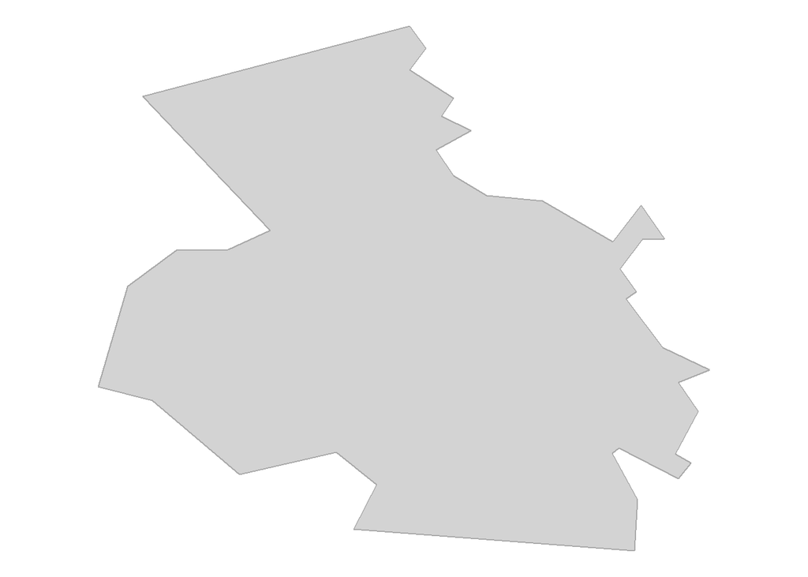

### 1.2 dataExport()

You can also export any OSMtidy output using the function `dataExport()`. The export file names have the following convention:

- Location name
- Step number (e.g. 1)
- Step name (e.g. dataShapefile)
- A timestamp of when the output was exported

```r
dataExport(shp, "exampleEdinburgh")
```

```
## File saved as: exampleEdinburgh_1_dataShapefile_20210111-155053.RDS
```

## 2. Extract - Using dataExtract()

The OpenStreetMap data is extracted, via the R package osmdata and the overpass server, using the function `dataExtract()`.

### 2.1 Features

This data is extracted by feature, and a vector of the names of features consisting of physical objects can be generated via `data("features")`. A vector of all the vailable features in osmdata can be accessed via the function `osmdata::available_features`.

```r
data("features")
features <- features[c(2,18,19,22,24)]; features # For this example we'll select a subset of 5 features
```

[output not shown]

```r
osmdata::available_features # A vector of all 209 available features
```

```
## function ()
## {
##     url_ftrs <- "https://wiki.openstreetmap.org/wiki/Map_Features"
##     if (curl::has_internet()) {
##         pg <- xml2::read_html(httr::GET(url_ftrs))
##         keys <- xml2::xml_attr(rvest::html_nodes(pg, "a[href^='/wiki/Key']"),
##             "href") %>% strsplit("/wiki/Key:") %>% unlist()
##         keys[keys != ""] %>% sort() %>% unique()
##     }
##     else {
##         message("No internet connection")
##     }
## }
## <bytecode: 0x0000000022b71ab8>
## <environment: namespace:osmdata>
```

### 2.2 dataExtract()

The function `dataExtract()` has three input arguments:

- *dataShapefile* The shapefile output from step 1
- *timeout* The time in seconds before the query to the overpass server will time out; see *Details* below
  - Default 300 seconds
- *memsize* The memory size for the overpass server; see *Details* below
  - Default 1073741824 Bytes

**Details from the R package osmdata**

> **timeout** It may be necessary to increase this value for large queries, because the server may time out before all data are delivered. **memsize** The default memory size for the ‘overpass’ server in bytes; may need to be increased in order to handle large queries.> See https://wiki.openstreetmap.org/wiki/Overpass_API#Resource_management_options_.28osm-script.29 for explanation of timeout and memsize (or maxsize in overpass terms). Note in particular the comment that queries with arbitrarily large memsize are likely to be rejected.

**Note** this function may take some time to run. Timestamps and progress are printed while the function is running. It is recommended that you execute the function once to avoid flooding the overpass server. The example below extracts 5 of the 47 features.

```r
dlExtract <- dataExtract(dataShapefile = shp, features = features)
```

```
## 10:47:59 Step one of two
```

```
## 10:47:59 Step two of two
```

```
## feature = aeroway, 1 out of 5 (20%); elapsed = 0.01314 mins
```

```
## feature = amenity, 2 out of 5 (40%); elapsed = 0.03059 mins
```

```
## feature = barrier, 3 out of 5 (60%); elapsed = 0.06188 mins
```

```
## feature = basin, 4 out of 5 (80%); elapsed = 0.09274 mins
```

```
## feature = bridge, 5 out of 5 (100%); elapsed = 0.12012 mins
```

```
## 10:48:06 Complete, preparing output
```

```r
dataSummary(dlExtract)
```

```
## $class
## [1] "list"                "OSMtidy_dataExtract"
##
## $byGeometry
##            type total
## 1         lines  4782
## 2 multipolygons     3
## 3        points 23180
## 4      polygons   610
##
## $byFeature
##   feature total
## 1 amenity  7165
## 2 barrier 21311
## 3  bridge    99
```

```r
dataExport(dlExtract, "exampleEdinburgh")
```

```
## File saved as: exampleEdinburgh_2_dataExtract_20210108-104806.RDS
```

## 3. Cut - Using dataCut()

In step 2 the data was extracted as a “bounding box” (a rectangle). In step 3, the data is cut to the shapefile using the function `dataCut()`.

The function `dataCut` has two input arguments:

- **dataExtracted** Output from step 2
- **dataShapefile** Output from step 1

Timestamps and progress are printed when the function is running.

```r
dlCut <- dataCut(dataExtracted = dlExtract, dataShapefile = shp)
```

```
## 10:48:07 Step one of four
```

```
## 10:48:07 Step two of four
```

```
## 10:48:07 Step three of four
```

```
## 10:48:08 Step four of four
```

```
## 10:48:08 Complete, preparing output
```

```r
dataSummary(dlCut)
```

```
## $class
## [1] "list"            "OSMtidy_dataCut"
##
## $byGeometry
##           type total
## 1   linestring  2885
## 2 multipolygon    15
## 3        point 13049
## 4      polygon   353
##
## $byFeature
##   feature total
## 1 amenity  4092
## 2 barrier 12142
## 3  bridge    68
```

```r
dataExport(dlCut, "exampleEdinburgh")
```

```
## File saved as: exampleEdinburgh_3_dataCut_20210108-104808.RDS
```

## 4. Wrangle - Using dataWrangle()

Using the function `dataWrangle` we can tidy up (or wrangle) the data before filtering.

There is one input argument:

- **dataCut** Output from step 3

Timestamps and progress are printed when the function is running.

```r
dlWrangle <- dataWrangle(dataCut = dlCut)
```

```
## 10:50:09 Step one of three
```

```
## 10:50:09 Step two of three
```

```
## 10:50:09 Step three of three
```

```
## 10:50:09 Complete, preparing output
```

```r
dataSummary(dlWrangle)
```

```
## $class
## [1] "list"                "OSMtidy_dataWrangle"
##
## $byGeometry
##           data            type total percent
## 1 dataWrangled      linestring  2880   17.68
## 2 dataWrangled multilinestring     5    0.03
## 3 dataWrangled    multipolygon     3    0.02
## 4 dataWrangled           point   568    3.49
## 5 dataWrangled         polygon   362    2.22
## 6     noDetail           point 12465   76.54
## 7     noDetail         polygon     2    0.01
##
## $byFeature
##           data feature total percent
## 1 dataWrangled amenity   777    4.77
## 2 dataWrangled barrier  3001   18.43
## 3 dataWrangled  bridge    23    0.14
## 4 dataWrangled    <NA>    17    0.10
## 5     noDetail amenity  3303   20.28
## 6     noDetail barrier  9124   56.03
## 7     noDetail  bridge    40    0.25
```

```r
dataExport(dlWrangle, "exampleEdinburgh")
```

```
## Files saved as:
```

```
##
##  exampleEdinburgh_4_dataWrangle_20210108-105010.RDS
##  exampleEdinburgh_4_dataWrangle-noDetail_20210108-105010.xlsx
```

## 5. Filter - Using dataFilter()

### 5.1 Filters

The main function of OSMtidy is `dataFilter()`. Here, the data is filtered based on rules set out in an Excel spreadsheet. Default filters, generated as part of the Water Resilient Cities project, can be accessed using the `data()` function: `data("filters")`.

```r
data("filters")
filters
```

```
## # A tibble: 1,232 x 7
##    searchColumn_con~ searchTerm        validate name1 name2 descTerm description
##    <chr>             <chr>             <lgl>    <chr> <chr> <chr>    <chr>
##  1 <NA>              changing room|ch~ TRUE     remo~ <NA>  remove   <NA>
##  2 amenity           biergarten|troll~ FALSE    remo~ <NA>  remove   <NA>
##  3 aeroway           airplane|stopway  FALSE    remo~ <NA>  remove   <NA>
##  4 building|man_made canopy|chimney|k~ FALSE    remo~ <NA>  remove   <NA>
##  5 emergency         marker            FALSE    remo~ <NA>  remove   <NA>
##  6 leisure           bird_hide|ball_d~ TRUE     remo~ <NA>  remove   <NA>
##  7 line              central|wood      FALSE    remo~ <NA>  remove   <NA>
##  8 natural           tree_stump|cave_~ TRUE     remo~ <NA>  remove   <NA>
##  9 railway|service   junction|crossov~ FALSE    remo~ <NA>  remove   <NA>
## 10 shelter|shelter_~ weather_shelter|~ FALSE    remo~ <NA>  remove   <NA>
## # ... with 1,222 more rows
```

To see the spreadsheet the default filters are based on, or to access a template to create your own filters, generate the filepaths using the code below.

```r
system.file("extdata", "filters.xlsx", package = "OSMtidy")
```

```
## [1] "C:/Users/av57/Documents/R/win-library/4.0/OSMtidy/extdata/filters.xlsx"
```

```r
system.file("extdata", "filtersTemplate.xlsx", package = "OSMtidy")
```

```
## [1] "C:/Users/av57/Documents/R/win-library/4.0/OSMtidy/extdata/filtersTemplate.xlsx"
```

See vignette 3 for further details.

### 5.2 filterOverview()

A filter overview can be generated using the function `filterOverview()`. The input can be either the filepath as a string or as an object in R. Examples of both are provided below.

**filterOverview() with a filepath**

```r
filepath <- system.file("extdata", "filters.xlsx", package = "OSMtidyPackage")
filepath
```

```
## [1] "C:/Users/av57/Documents/R/win-library/4.0/OSMtidyPackage/extdata/filters.xlsx"
```

```r
filterOverview(filepath)
```

```
## $summary
## # A tibble: 3 x 4
##   type     `validate = FALSE` `validate = TRUE` total
##   <fct>                 <int>             <int> <int>
## 1 filter                  981               124  1105
## 2 keywords                 NA                44    44
## 3 remove                   59                24    83
##
## $filter
## # A tibble: 624 x 3
##    name1   name2                         descTerm
##    <chr>   <chr>                         <chr>
##  1 Airport Aerodrome, terminal and gates Airport; Aerodrome, terminal and gates
##  2 Amenity ATM                           Amenity; ATM
##  3 Amenity Automatic number plate reader Amenity; Automatic number plate reader
##  4 Amenity Bandstand                     Amenity; Bandstand
##  5 Amenity BBQ point                     Amenity; BBQ point
##  6 Amenity Bicycle parking               Amenity; Bicycle parking
##  7 Amenity Bike monitoring               Amenity; Bike monitoring
##  8 Amenity Bike rental point             Amenity; Bike rental point
##  9 Amenity Boat mooring                  Amenity; Boat mooring
## 10 Amenity Car wash                      Amenity; Car wash
## # ... with 614 more rows
##
## $keywords
## # A tibble: 43 x 3
##    name1          name2                 descTerm
##    <chr>          <chr>                 <chr>
##  1 Keyword filter A&E                   Keyword filter; A&E
##  2 Keyword filter Alteration            Keyword filter; Alteration
##  3 Keyword filter Animal racing         Keyword filter; Animal racing
##  4 Keyword filter Auditoriums           Keyword filter; Auditoriums
##  5 Keyword filter Banking               Keyword filter; Banking
##  6 Keyword filter Barber                Keyword filter; Barber
##  7 Keyword filter Business and commerce Keyword filter; Business and commerce
##  8 Keyword filter Cabinet               Keyword filter; Cabinet
##  9 Keyword filter Catering college      Keyword filter; Catering college
## 10 Keyword filter Centres               Keyword filter; Centres
## # ... with 33 more rows
##
## attr(,"class")
## [1] "list"                   "OSMtidy_filterOverview"
```

**filterOverview() with an R object**

```r
data("filters")
filters
```

```
## # A tibble: 1,232 x 7
##    searchColumn_con~ searchTerm        validate name1 name2 descTerm description
##    <chr>             <chr>             <lgl>    <chr> <chr> <chr>    <chr>
##  1 <NA>              changing room|ch~ TRUE     remo~ <NA>  remove   <NA>
##  2 amenity           biergarten|troll~ FALSE    remo~ <NA>  remove   <NA>
##  3 aeroway           airplane|stopway  FALSE    remo~ <NA>  remove   <NA>
##  4 building|man_made canopy|chimney|k~ FALSE    remo~ <NA>  remove   <NA>
##  5 emergency         marker            FALSE    remo~ <NA>  remove   <NA>
##  6 leisure           bird_hide|ball_d~ TRUE     remo~ <NA>  remove   <NA>
##  7 line              central|wood      FALSE    remo~ <NA>  remove   <NA>
##  8 natural           tree_stump|cave_~ TRUE     remo~ <NA>  remove   <NA>
##  9 railway|service   junction|crossov~ FALSE    remo~ <NA>  remove   <NA>
## 10 shelter|shelter_~ weather_shelter|~ FALSE    remo~ <NA>  remove   <NA>
## # ... with 1,222 more rows
```

```r
filterOverview(filters)
```

```
## $summary
## # A tibble: 3 x 4
##   type     `validate = FALSE` `validate = TRUE` total
##   <fct>                 <int>             <int> <int>
## 1 filter                  981               124  1105
## 2 keywords                 NA                44    44
## 3 remove                   59                24    83
##
## $filter
## # A tibble: 624 x 3
##    name1   name2                         descTerm
##    <chr>   <chr>                         <chr>
##  1 Airport Aerodrome, terminal and gates Airport; Aerodrome, terminal and gates
##  2 Amenity ATM                           Amenity; ATM
##  3 Amenity Automatic number plate reader Amenity; Automatic number plate reader
##  4 Amenity Bandstand                     Amenity; Bandstand
##  5 Amenity BBQ point                     Amenity; BBQ point
##  6 Amenity Bicycle parking               Amenity; Bicycle parking
##  7 Amenity Bike monitoring               Amenity; Bike monitoring
##  8 Amenity Bike rental point             Amenity; Bike rental point
##  9 Amenity Boat mooring                  Amenity; Boat mooring
## 10 Amenity Car wash                      Amenity; Car wash
## # ... with 614 more rows
##
## $keywords
## # A tibble: 43 x 3
##    name1          name2                 descTerm
##    <chr>          <chr>                 <chr>
##  1 Keyword filter A&E                   Keyword filter; A&E
##  2 Keyword filter Alteration            Keyword filter; Alteration
##  3 Keyword filter Animal racing         Keyword filter; Animal racing
##  4 Keyword filter Auditoriums           Keyword filter; Auditoriums
##  5 Keyword filter Banking               Keyword filter; Banking
##  6 Keyword filter Barber                Keyword filter; Barber
##  7 Keyword filter Business and commerce Keyword filter; Business and commerce
##  8 Keyword filter Cabinet               Keyword filter; Cabinet
##  9 Keyword filter Catering college      Keyword filter; Catering college
## 10 Keyword filter Centres               Keyword filter; Centres
## # ... with 33 more rows
##
## attr(,"class")
## [1] "list"                   "OSMtidy_filterOverview"
```

### 5.3 Application

There are three input arguments to `dataFilter()`:

- **dataWrangle** Output from step 4
- **filters** The filepath of the filters as a string or as an object in R (see `filterOverview()` previously)
- **rows** Specify the rows in the filters object to apply. Intended for troubleshooting and adjusting filters
  - Default to NULL, i.e. all filters (rows)

Timestamps and progress are printed when the function is running.

Depending on the location size, number of filters and computer performance, filters can take anything from a couple of minutes (the example ward) to multiple hours to run (City of London and Boroughs).

```r
dlFilter <- dataFilter(dataWrangle = dlWrangle, filters = filters)
dataSummary(dlFilter)
```

```
## $class
## [1] "list"               "OSMtidy_dataFilter"
##
## $summary
##         data total percent
## 1   filtered  3781   99.03
## 2 unfiltered     1    0.03
## 3   validate    36    0.94
##
## $summaryFiltered
## # A tibble: 71 x 2
##    desc                                 total
##    <chr>                                <int>
##  1 Amenity; ATM                            14
##  2 Amenity; Bicycle parking                55
##  3 Amenity; Bike rental point               6
##  4 Amenity; Car wash                        2
##  5 Amenity; Electric car charging point     2
##  6 Amenity; Flood defence                   2
##  7 Amenity; Fountain (decorative)           1
##  8 Amenity; Fuel station                    1
##  9 Amenity; Grit bin                        2
## 10 Amenity; Outdoor seating                22
## # ... with 61 more rows
##
## $byFeature
##         data feature total
## 1 unfiltered amenity     1
## 2   validate amenity     3
## 3   validate    <NA>    33
```

```r
dataExport(dlFilter, "exampleEdinburgh")
```

[output not shown]

## 6. Tidy - Using dataTidy()

Note that multiple outputs from `dataWrangle()` and `dataFilter()` were spreadsheets (.xlsx extension). These spreadsheets may be manually adjusted; this is covered in the third vignette.

The function `dataTidy()` generates a single tidied output based on any combination (R object and/or spreadsheet) of this filtered, validated, unfiltered and no detail data.

There is one input argument to `dataTidy()`:

- **datalist** A list of R objects and/or spreadsheet.

In this vignette, the input is the list of outputs from steps 4 and 5. In vignettes 3 and 4 a number of alternative approaches are described.

**The tidied geotagged dataset is saved in .RDS, and .csv for use in a range of applications. To export as a shapefile it is necessary to split the geotagged dataset by geometry type first. Still need to update how the final output works and runs**

```r
dlTidy <-
  dataTidy(dataList =
             list(dlWrangle$noDetail,
                  dlFilter$unfiltered,
                  dlFilter$filtered,
                  dlFilter$validate))
dataSummary(dlTidy)
```

```
## $class
## [1] "list"             "OSMtidy_dataTidy"
##
## $summary
## # A tibble: 3 x 3
##   data       total percent
##   <chr>      <int>   <dbl>
## 1 unfiltered 12468   76.6
## 2 remove       145    0.89
## 3 filtered    3672   22.6
##
## $summaryFiltered
## # A tibble: 73 x 2
##    desc                                 total
##    <chr>                                <int>
##  1 Amenity; ATM                            14
##  2 Amenity; Bicycle parking                55
##  3 Amenity; Bike rental point               6
##  4 Amenity; Car wash                        2
##  5 Amenity; Electric car charging point     2
##  6 Amenity; Flood defence                   2
##  7 Amenity; Fountain (decorative)           1
##  8 Amenity; Fuel station                    1
##  9 Amenity; Grit bin                        2
## 10 Amenity; Outdoor seating                22
## # ... with 63 more rows
##
## $unfiltered
## # A tibble: 3 x 2
##   feature total
##   <chr>   <int>
## 1 amenity  3304
## 2 barrier  9124
## 3 bridge     40
```

```r
dataExport(dlTidy, "exampleEdinburgh")
```

```
## Files saved as:
```

```
##
##  exampleEdinburgh_6_dataTidy-unfiltered_20210111-155054.RDS
##  exampleEdinburgh_6_dataTidy-remove_20210111-155055.RDS
##  exampleEdinburgh_6_dataTidy-filtered_20210111-155055.RDS
##  exampleEdinburgh_6_dataTidy-filtered_20210111-155055.csv
```